# 320d Austin Animal Center Report

## Introduction and restatement of requirements

In this project, we have been tasked to create a data pipeline that shares insights about the animals that have been taken into the Austin Animal Center (AAC) over the years. As a group, we are all responsible for contributing to and understanding each part of the project. This project is supposed to mirror the example data pipeline that was demonstrated to us during the first 10 weeks of the semester. We are responsible for understanding the data we have been given, load the data into Superset, creating the dimensional model, creating and running the dbt model files, designing our data products, and creating the visualizations.

Our job was the help the AAC director and staff understand the flow of animals entering and leaving the shelter by providing the answers to the following questions:

1. What is the average number of days in AAC for an animal? By animal type By animal type and breed By year by animal type
2. How many animals come into AAC every year, and how many go out?
3. What are the 3 busiest months (by number of intakes) and what are the 3 slowest months?
4. Which animal type has the most adoptions?

Next, one can see the answers along with the steps we took to get there.

## Data Ingestion

### Documentation for source data

- Examples of Concrete data

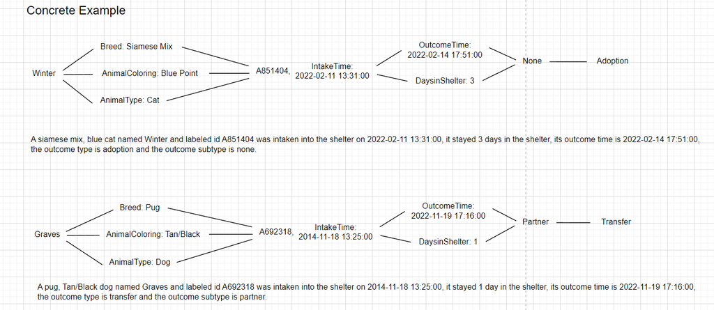

- Conceptual ER

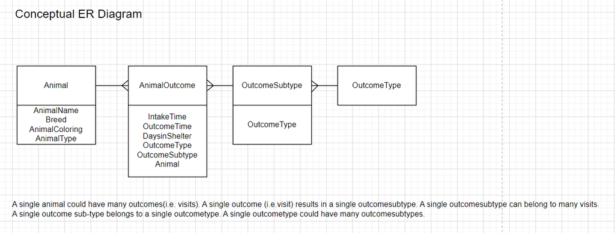

- Physical ER

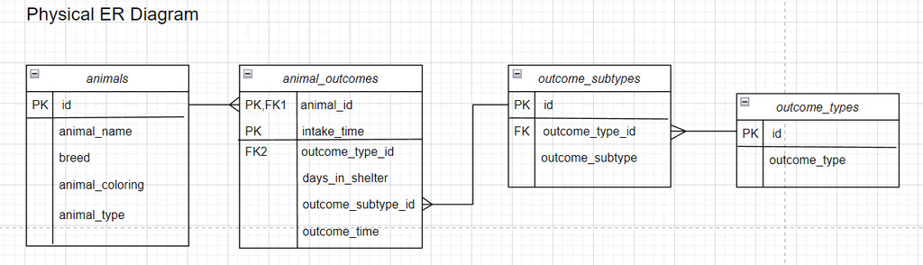

- Sample tables (screenshots are sufficient)
1. animal outcomes

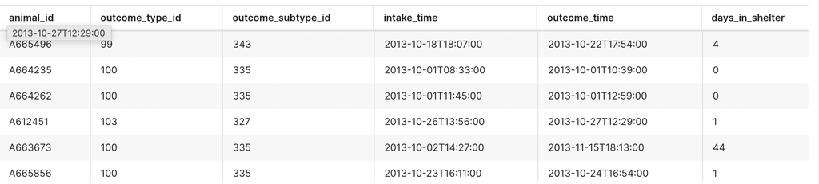

2. animals

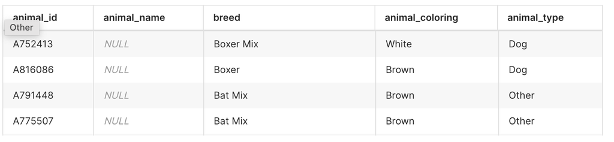

3. outcome subtypes

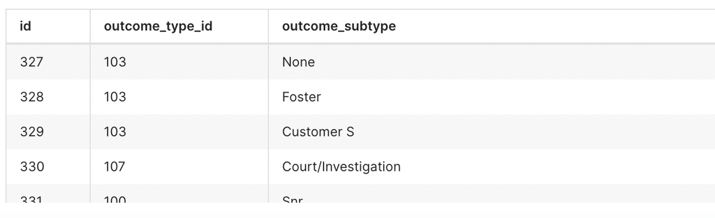

4. outcome types

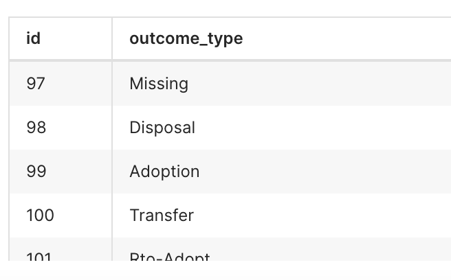